# Is there a link between worsening of mental health and lack of central heating?

B209732

2025-12-01

A study by Clair and Baker (2022) has reported that living in cold homes could have detrimental effects on mental health. Their study, carried out in the UK, has found an increase in mental distress in participants who were unable to keep their house warm. The mental distress experienced by the participants in the study could be attributed to reduced feelings of autonomy, effects on sleep and as a result of feeling cold all the time. The latter is of particular concern in winter months (Clair and Baker, 2022).

Winter is a time in which some people may experience seasonal affective disorder (SAD), as a result of being exposed to less hours of light. This is a type of depression and could be exacerbated by factors such as living in colder houses, such as those lacking central heating ( *Understanding seasonal affective disorder (SAD)*, 2025). By looking at the data available in the Scottish Census 2022, a number of households across Scotland currently have no heating.

This report will investigate the link between cold housing conditions and SAD/mental distress by looking at antidepressants (ADs) prescription across all the Health Boards in Scotland. This is because ADs are commonly prescribed as a treatment for SAD and mental distress such as increased anxiety. Data across Health Boards will be used to identify patterns across Scotland. ( *Overview - seasonal affective disorder (SAD)*, 2025).

**The importance of this investigation is to gain the government’s attention regarding housing conditions and its importance in relation to mental health (Clair and Baker, 2022)**

```r
#Data packages used
library(tidyverse)
library(janitor)
library(gt)
library(here)
library(dplyr)
library(ggplot2)
```

The data used in this report can be found in the Public Health Scotland data sets and Scottish Census 2022:

- Prescription data: https://www.opendata.nhs.scot/dataset/prescriptions-in-the-community/resource/9de908b3-9c28-4cc3-aa32-72350a0579d1
- Health Boards (HB) names and codes: https://www.opendata.nhs.scot/dataset/geography-codes-and-labels/resource/652ff726-e676-4a20-abda-435b98dd7bdc
- housing data: https://www.scotlandscensus.gov.uk/webapi/jsf/tableView/tableView.xhtml (Scotland’s Census 2022 - National Records of Scotland, Table UV407 - Central heating)
- population data: https://www.scotlandscensus.gov.uk/webapi/jsf/tableView/tableView.xhtml (Scotland’s Census 2022 - National Records of Scotland, Table UV102a - Age (single year) by sex All people)

```r
#Open data - January 2025 to June 2025
data_jan_to_june2025 <- read_csv("https://www.opendata.nhs.scot/dataset/84393984-14e9-4b0d-a797-b288db64d088/resource/9de908b3-9c28-4cc3-aa32-72350a0579d1/download/hb_pitc2025_01_06.csv")%>%
  clean_names()

#Health Boards names and codes
HB_lookup <- read_csv("https://www.opendata.nhs.scot/dataset/9f942fdb-e59e-44f5-b534-d6e17229cc7b/resource/652ff726-e676-4a20-abda-435b98dd7bdc/download/hb14_hb19.csv") %>%
  clean_names()

#Central heating data
central_heating <- read_csv(here("data", "central_heating.csv"), skip = 10) %>% #skip the first 10 rows
  clean_names() %>%
rename(hb_name = "health_board_area_2019",
      n_households = "count") %>%
  select(hb_name, central_heating_in_household, n_households) %>%
  filter(central_heating_in_household == "No central heating") %>% #only keep relevant information
   mutate(hb_name = paste("NHS", hb_name))# change health board names so they match the prescription data

#Population data
population_data <- read_csv(here("data/UV102a_age_health_board_census.csv"), skip = 10) %>%
  # Rename the last column to avoid the messy name in column 6 and to match column names with the prescription dataset
  rename(Spare = "...6",
         hb_name = "Health Board Area 2019",
         hb_population = Count) %>%
  filter(Age == "All people" & Sex == "All people") %>% # filter the data so that we get the population of the entire health board
  # select only the relevant columns
  select(hb_name, hb_population) %>%
  mutate(hb_name = paste("NHS", hb_name))
```

For this report, the focus will be on the prescription of selective serotonin re-uptake inhibitors (SSRIs) such as Sertraline, Citalopram, Escitalopram, Fluoxetine and Paroxetine, of all formulations ( *Antidepressants*, 2025).

```r
#filter SSRIs
data_jan_to_june2025 <- data_jan_to_june2025 %>%
  filter(str_detect(bnf_item_description, "SERTRALINE|CITALOPRAM|ESCITALOPRAM|FLUOXETINE|PAROXETINE")) %>%
  full_join(HB_lookup, by = c("hbt" = "hb")) %>% #joined the Health Board data with names and codes
  mutate(Months = str_replace_all(paid_date_month ,c('202501'='January', '202502'='February', '202503'='March', '202504'='April', '202505'='May', '202506'='June'))) %>%  #replaced the numerical date with a character one
  full_join(population_data) %>% #joined the population data
  mutate(AD_per_1k = (paid_quantity/hb_population)*1000) #Since each Health Board has different populations, the AD prescription per 1000 people will be used for comparison
```

We will start the investigation by looking at the distribution of AD prescription from January to June 2025

**Figure 1: AD prescription per month (January to June 2025)**

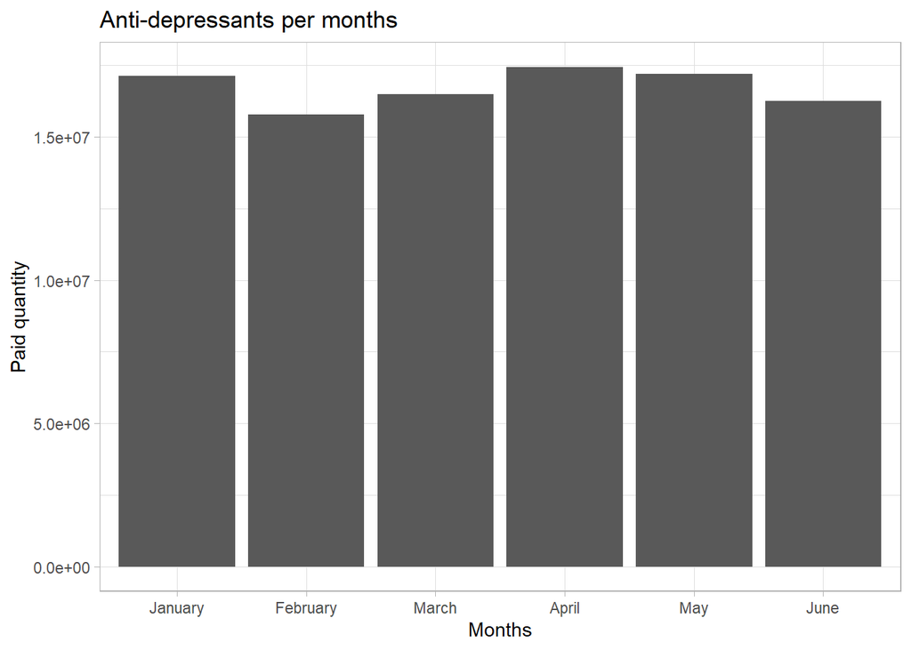

```r
data_jan_to_june2025 %>%
  select(paid_quantity, Months) %>%
  drop_na() %>%
  group_by(Months) %>%
  ggplot(aes(x = fct_inorder(Months), y = paid_quantity)) + #to make sure ggplot doesn't order months alphabetically
  geom_col() +
  labs(y = "Paid quantity",
       x = "Months",
       title = "Anti-depressants per months") +
  theme_light()
```

*Figure 1 shows that there doesn’t seem to be a trend between AD prescription and seasons but rather that a month with high prescription usually follows two months with lower prescriptions. This suggests that colder temperatures are not associated with increased SAD/mental distress in people living in Scotland compared to warmer temperatures.*

Now we are going to look at whether Health Boards trends are stable across months, to identify whether some parts of Scotland are affected by seasons more than others.

**Figure 2: Comparison of AD prescription/1k population per Health Boards, from January to June 2025**

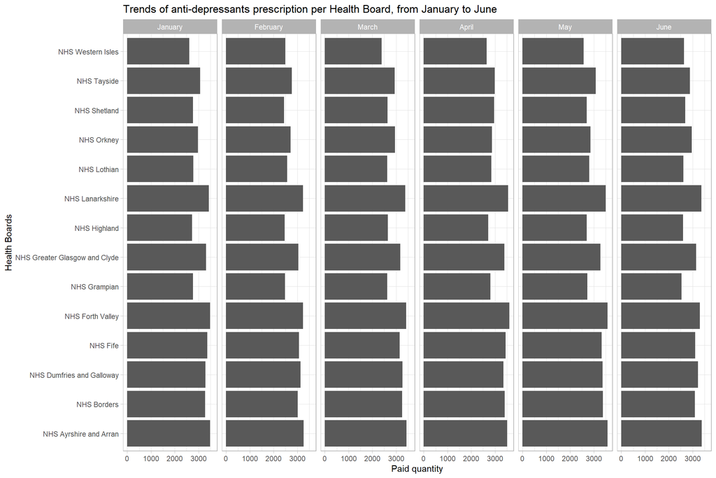

```r
data_jan_to_june2025 %>%
  select(AD_per_1k, Months, hb_name) %>%
  drop_na() %>%
  group_by(hb_name) %>%
   ggplot(aes(x = hb_name, y = AD_per_1k)) +
  geom_col() +
  labs(y = "Paid quantity",
       x = "Health Boards",
       title = "Trends of anti-depressants prescription per Health Board, from January to June") +
  theme_light() +
  coord_flip() +
  facet_grid(cols = vars(fct_inorder(Months)))
```

Next, we are going to look at whether colder houses are correlated with higher prescription of ADs.

First, we are going to look at the number of households lacking central heating according to the Scottish Census 2022.

```r
central_heating_per_HB <- data_jan_to_june2025 %>%
  select(hb_name, AD_per_1k, hb_population) %>%
  group_by(hb_name, hb_population) %>%
  reframe(total_AD_per_HB_per_1k = sum(AD_per_1k, na.rm = TRUE)) %>% #used reframe instead of summarise to avoid warning message
  full_join(central_heating) %>%
  mutate(household_per_1k = (n_households/hb_population)*1000)
#since each Health Board has different populations, each one will also have a different number of households, therefore we will look at number of households per 1k population
```

**Table 1: Number of households lacking central heating/1k population across Health Boards**

```r
central_heating_per_HB %>%
   select(hb_name, household_per_1k) %>%
  drop_na() %>%
    gt() %>%
  cols_label(household_per_1k = "Number of households", hb_name = "Health Boards") %>%
  tab_header(title = "Total number of households without central heating per 1k population",
             subtitle = "Data from NHS Borders and NHS Fife")
```

Total number of households without central heating per 1k population

| Health Boards | Number of households |
| --- | --- |
| NHS Ayrshire and Arran | 6.206606 |
| NHS Borders | 9.963962 |
| NHS Dumfries and Galloway | 9.136708 |
| NHS Fife | 5.210056 |
| NHS Forth Valley | 6.086847 |
| NHS Grampian | 8.765317 |
| NHS Greater Glasgow and Clyde | 11.700516 |
| NHS Highland | 16.145848 |
| NHS Lanarkshire | 6.561112 |
| NHS Lothian | 11.097379 |
| NHS Orkney | 21.404499 |
| NHS Shetland | 17.401897 |
| NHS Tayside | 10.715183 |
| NHS Western Isles | 17.100230 |

*From table 1 we can see that some Health Boards have more houses with no heating compared to others, with the highest number attributed to NHS Orkney.*

**Therefore, will AD prescription be higher in those Health Boards?** If so, then there might be a link between cold houses and worsening of mental health.

**Figure 3:Comparison of ADs and lack of central heating/1k population**

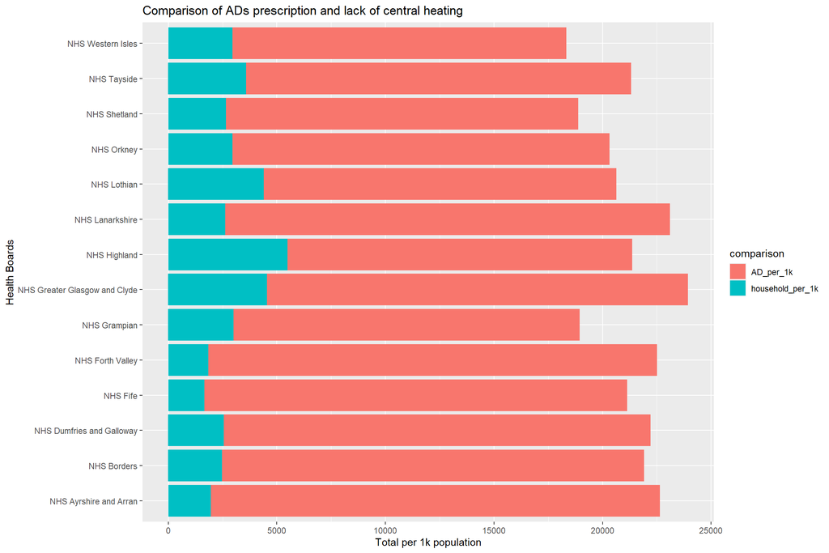

```r
AD_and_heating_comparison <- data_jan_to_june2025 %>%
  full_join(central_heating_per_HB) %>%
  select(hb_name, household_per_1k, AD_per_1k) %>%
  drop_na() %>%
  pivot_longer(cols = !hb_name, names_to = "comparison", values_to = "total_per_1k_population")#to aid the making of a stacked bar chart


AD_and_heating_comparison %>%
  ggplot(aes(fill = comparison, y = total_per_1k_population, x = hb_name))+
    geom_bar(position = "stack", stat = "identity")+
  labs(y = "Total per 1k population",
       x = "Health Boards",
       title = "Comparison of ADs prescription and lack of central heating")+
    coord_flip()
```

*Figure 3 shows that there doesn’t seem to be a link between lack of central heating and AD prescription. As we can see, one of the bars with the highest proportion of households without heating eg. NHS Highland, has a smaller proportion of AD prescription compared to eg. NHS Forth Valley which has one of the smallest proportions of households lacking central heating but has a greater proportion of AD prescription (Yi, no date).*

Overall, we can conclude that in Scotland, there doesn’t seem to be a recent worsening of mental health related to colder temperatures and lack of central heating. Nevertheless, cold housing conditions can still affect the health and wellbeing of individuals and therefore the government should still ensure that people live in good housing conditions.

Future studies should focus on comparing monthly trends from January to December, to give a more comprehensive view of seasonal patterns. Moreover, links between AD prescription and lack of central heating could be looked at further by investigating, for example, whether the elderly, who are more likely to spend time at home, are more affected compared to other age groups, or whether trends change depending on demographics (Clair, Baker, 2022).

**REFERENCES:**

Clair A, Baker E (2022). Cold homes and mental health harm: evidence from the UK household longitudinal study. Social Science & Medicine, 115461. https://doi.org/10.1016/j.socscimed.2022.115461

*Understanding seasonal affective disorder (SAD)* (2025) Available at: https://www.mind.org.uk/information-support/types-of-mental-health-problems/seasonal-affective-disorder-sad/understanding-your-experiences/ (Accessed: November 30th, 2025)

*Overview - seasonal affective disorder* (SAD) (2025) Available at: https://www.nhs.uk/mental-health/conditions/seasonal-affective-disorder-sad/overview/ (Accessed: November 13th, 2025)

*Antidepressants* (2025) Available at: https://www.nhs.uk/medicines/antidepressants/ (Accessed: November 30th 2025)

Yi M (no date) *A complete guide to stacked bar charts*. Available at: https://www.atlassian.com/data/charts/stacked-bar-chart-complete-guide (Accessed: November 30th, 2025)